# Introduction aux Modèles Mixtes

Paul Bastide

2025-12-16

# From ANOVA to Mixed Models

## Sleep Study

```r
library(lme4)
kable(head(sleepstudy))
```

| Reaction | Days | Subject |
| --- | --- | --- |
| 249.5600 | 0 | 308 |
| 258.7047 | 1 | 308 |
| 250.8006 | 2 | 308 |
| 321.4398 | 3 | 308 |
| 356.8519 | 4 | 308 |
| 414.6901 | 5 | 308 |

## Sleep Study

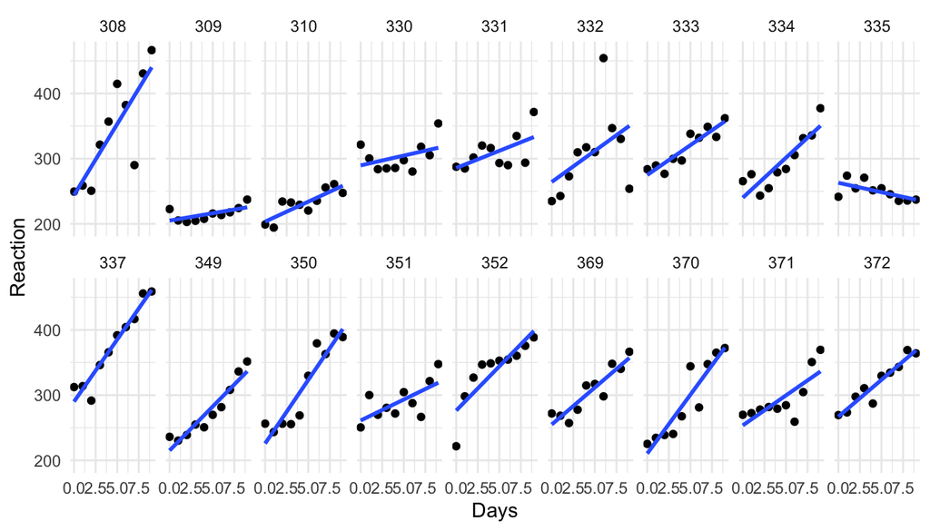

## ANCOVA

For observation $i$ of group $k$:
$$y_{i,k} = \mu + \alpha_k + (\beta + \gamma_k) \times x_{i} + \epsilon_{i, k}$$

- $\mu$ the intercept
- $\alpha_k$ the specific effect of group $k$ on the intercept
- $\gamma_k$ the specific effect of group $k$ on the slope
- $\epsilon_{i, k} \sim \mathcal{N}(0, \sigma^2)$ iid noise.

**Problem**: What if there are many groups, with few observations?  
$\to$ Estimation problem.

## ANCOVA

```r
fit_ancova <- lm(Reaction ~ Days * Subject, data = sleepstudy)
summary(fit_ancova)
```

```
Call:
lm(formula = Reaction ~ Days * Subject, data = sleepstudy)

Residuals:
     Min       1Q   Median       3Q      Max
-106.397  -10.692   -0.177   11.417  132.510

Coefficients:
                Estimate Std. Error t value Pr(>|t|)
(Intercept)      244.193     15.042  16.234  < 2e-16 ***
Days              21.765      2.818   7.725 1.74e-12 ***
Subject309       -39.138     21.272  -1.840 0.067848 .
Subject310       -40.708     21.272  -1.914 0.057643 .
Subject330        45.492     21.272   2.139 0.034156 *
Subject331        41.546     21.272   1.953 0.052749 .
Subject332        20.059     21.272   0.943 0.347277
Subject333        30.826     21.272   1.449 0.149471
Subject334        -4.030     21.272  -0.189 0.850016
Subject335        18.842     21.272   0.886 0.377224
Subject337        45.911     21.272   2.158 0.032563 *
Subject349       -29.081     21.272  -1.367 0.173728
Subject350       -18.358     21.272  -0.863 0.389568
Subject351        16.954     21.272   0.797 0.426751
Subject352        32.179     21.272   1.513 0.132535
Subject369        10.775     21.272   0.507 0.613243
Subject370       -33.744     21.272  -1.586 0.114870
Subject371         9.443     21.272   0.444 0.657759
Subject372        22.852     21.272   1.074 0.284497
Days:Subject309  -19.503      3.985  -4.895 2.61e-06 ***
Days:Subject310  -15.650      3.985  -3.928 0.000133 ***
Days:Subject330  -18.757      3.985  -4.707 5.84e-06 ***
Days:Subject331  -16.499      3.985  -4.141 5.88e-05 ***
Days:Subject332  -12.198      3.985  -3.061 0.002630 **
Days:Subject333  -12.623      3.985  -3.168 0.001876 **
Days:Subject334   -9.512      3.985  -2.387 0.018282 *
Days:Subject335  -24.646      3.985  -6.185 6.07e-09 ***
Days:Subject337   -2.739      3.985  -0.687 0.492986
Days:Subject349   -8.271      3.985  -2.076 0.039704 *
Days:Subject350   -2.261      3.985  -0.567 0.571360
Days:Subject351  -15.331      3.985  -3.848 0.000179 ***
Days:Subject352   -8.198      3.985  -2.057 0.041448 *
Days:Subject369  -10.417      3.985  -2.614 0.009895 **
Days:Subject370   -3.709      3.985  -0.931 0.353560
Days:Subject371  -12.576      3.985  -3.156 0.001947 **
Days:Subject372  -10.467      3.985  -2.627 0.009554 **
---
Signif. codes:  0 '***' 0.001 '**' 0.01 '*' 0.05 '.' 0.1 ' ' 1

Residual standard error: 25.59 on 144 degrees of freedom
Multiple R-squared:  0.8339,    Adjusted R-squared:  0.7936
F-statistic: 20.66 on 35 and 144 DF,  p-value: < 2.2e-16
```

## Mixed Model

For observation $i$ of group $k$:
$$y_{i,k} = \mu + A_{k} + (\beta + G_k) \times x_{i} + \epsilon_i$$

- $\mu$ the intercept
- $A_k \sim \mathcal{N}(0, s_A^2)$ iid effect of group $k$ on the intercept
- $G_k \sim \mathcal{N}(0, s_G^2)$ iid effect of group $k$ on the slope
- $\epsilon_{ik} \sim \mathcal{N}(0, \sigma^2)$ iid noise.

$\to$ Replace **fixed effects** with **random effects**.

$\to$ **Idea**: works when there are many groups in a factor.

# Mixed Models

## Mixed Model - Simple Case

For observation $i$ of group $k$:
$$y_{i,k} = \mu + A_{k} + \epsilon_i$$

- $A_k \sim \mathcal{N}(0, s_A^2)$ iid
- $\epsilon_{ik} \sim \mathcal{N}(0, \sigma^2)$ iid noise.

$$\mathbb{E}[y_{i,k}] = \mu$$

$$\mathbb{V}[y_{i,k}] = s_A^2 + \sigma^2$$

$$\mathbb{C}[y_{i,k}, y_{i',k'}] =
\begin{cases}
s_A^2 & \text{if } k = k' \\
0 & \text{otherwise.}
\end{cases}$$

## Mixed Model - Simple Case

**ANOVA**
$$y_{i,k} = \mu + \alpha_{k} + \epsilon_{ik}
\quad \epsilon_{i,k} \sim \mathcal{N}(0, \sigma^2) ~ iid$$

$$\mathcal{H}_0: \alpha_1 = \cdots = \alpha_K = 0$$

**Mixed Model**
$$y_{i,k} = \mu + A_{k} + \epsilon_{ik}
\quad A_k \sim \mathcal{N}(0, s_A^2) ~ iid
\quad \epsilon_{i,k} \sim \mathcal{N}(0, \sigma^2) ~ iid$$

$$\mathcal{H}_0: s_A^2 = 0$$
**Different models** but **same question**: does the structure of the population in groups impact the mean of $y_{i,k}$ ?

## Mixed Model - Simple Case

$$y_{i,k} = \mu + A_{k} + \epsilon_i$$

$$\mathbf{y} = \mu\mathbf{1}_{nK} + \mathbf{Z}\mathbf{U} + \boldsymbol{\epsilon}$$

$$\mathbf{y}
= \text{vec}((y_{i,k})_{i, k})
= \begin{pmatrix}
y_{1,1}\\
y_{2,1}\\
\vdots\\
y_{n, 1}\\
y_{1, 2}\\
\vdots\\
y_{n, 2}\\
\vdots\\
y_{n, K}
\end{pmatrix}
\qquad
\mathbf{Z}
=
\begin{pmatrix}
1 & 0 & \cdots & 0\\
\vdots & \vdots & \vdots & \vdots\\
1 & 0 & \cdots & 0\\
0 & 1 & \cdots & 0\\
\vdots & \vdots & \vdots & \vdots\\
0 & 1 & \cdots & 0\\
0 & 0 & \cdots & 1\\
\vdots & \vdots & \vdots & \vdots\\
0 & 0 & \cdots & 1\\
\end{pmatrix}
\qquad
\begin{aligned}
\mathbf{U} &\sim \mathcal{N}(\mathbf{0}, s_A^2\mathbf{I}_{K}) \\
\boldsymbol{\epsilon} &\sim \mathcal{N}(\mathbf{0}, \sigma^2\mathbf{I}_{nK})
\end{aligned}$$

## Mixed Model - Simple Case

$$y_{i,k} = \mu + A_{k} + \epsilon_i$$

$$~$$

$$\mathbf{y} = \mu\mathbf{1}_{nK} + \mathbf{E}
\qquad
\mathbf{E} \sim \mathcal{N}(\mathbf{0}, \mathbf{\Sigma})$$

$$~$$

$$\mathbf{\Sigma}
=
\begin{pmatrix}
\mathbf{R} & \mathbf{0} & \cdots & \mathbf{0}\\
\mathbf{0} & \ddots & \ddots & \vdots\\
\vdots & \ddots & \ddots & \mathbf{0}\\
\mathbf{0} & \cdots & \mathbf{0} & \mathbf{R}\\
\end{pmatrix}
\qquad
\mathbf{R}
=
\begin{pmatrix}
\sigma^2 + s_A^2 & s_A^2 & \cdots & s_A^2\\
s_A^2 & \ddots & \ddots & \vdots\\
\vdots & \ddots & \ddots & s_A^2\\
s_A^2 & \cdots & s_A^2 & \sigma^2 + s_A^2\\
\end{pmatrix}$$

## Mixed Model - General Case

**Linear Model**
$$\mathbf{y} \sim \mathcal{N}(\mathbf{X}\boldsymbol{\beta}, \sigma^2 \mathbf{I}_n)$$

$$~$$

**Mixed Model**
$$\mathbf{y} \sim \mathcal{N}(\mathbf{X}\boldsymbol{\beta}, \mathbf{\Sigma})$$

$$~$$
with $\mathbf{\Sigma}$ structured covariance matrix.

# Sleep dataset example

## Mixed Model - Sleep

For observation $i$ of group $k$:
$$y_{i,k} = \mu + A_{k} + (\beta + G_k) \times x_{i} + \epsilon_i$$

- $A_k \sim \mathcal{N}(0, s_A^2)$ iid effect of group $k$ on the intercept
- $G_k \sim \mathcal{N}(0, s_G^2)$ iid effect of group $k$ on the slope
- $\epsilon_{ik} \sim \mathcal{N}(0, \sigma^2)$ iid noise.

$$\mathbb{E}[y_{i,k}] = \mu + \beta x_i$$

$$\mathbb{V}[y_{i,k}] = s_A^2 + s_G^2x_i^2 + \sigma^2$$

$$\mathbb{C}[y_{i,k}, y_{i',k'}] =
\begin{cases}
s_A^2 + s_G^2 x_i x_{i'}& \text{if } k = k' \\
0 & \text{otherwise.}
\end{cases}$$

## Mixed Model - Sleep

$$y_{i,k} = \mu + A_{k} + (\beta + G_k) \times x_{i} + \epsilon_i$$

$$\mathbf{y} = \mu\mathbf{1}_{nK} + \beta \mathbf{x}
+ \mathbf{Z}_1\mathbf{U}_1
+ \mathbf{Z}_2\mathbf{U}_2 + \boldsymbol{\epsilon}$$

$$\mathbf{y}
= \begin{pmatrix}
y_{1,1}\\
y_{2,1}\\
\vdots\\
y_{n, 1}\\
y_{1, 2}\\
\vdots\\
y_{n, 2}\\
\vdots\\
y_{n, K}
\end{pmatrix}
\qquad
\mathbf{Z}_2
=
\begin{pmatrix}
x_1 & 0 & \cdots & 0\\
\vdots & \vdots & \vdots & \vdots\\
x_n & 0 & \cdots & 0\\
0 & x_1 & \cdots & 0\\
\vdots & \vdots & \vdots & \vdots\\
0 & x_n & \cdots & 0\\
0 & 0 & \cdots & x_1\\
\vdots & \vdots & \vdots & \vdots\\
0 & 0 & \cdots & x_n\\
\end{pmatrix}
\qquad
\begin{aligned}
\mathbf{U}_1 &\sim \mathcal{N}(\mathbf{0}, s_A^2\mathbf{I}_{K}) \\
\mathbf{U}_2 &\sim \mathcal{N}(\mathbf{0}, s_G^2\mathbf{I}_{K}) \\
\boldsymbol{\epsilon} &\sim \mathcal{N}(\mathbf{0}, \sigma^2\mathbf{I}_{nK})
\end{aligned}$$

## Mixed Model - Sleep

$$y_{i,k} = \mu + A_{k} + (\beta + G_k) \times x_{i} + \epsilon_i$$

$$\mathbf{y} = \mu\mathbf{1}_{nK} + \beta \mathbf{x}
+ \mathbf{Z}_1\mathbf{U}_1
+ \mathbf{Z}_2\mathbf{U}_2 + \boldsymbol{\epsilon}$$

$$\mathbf{y} = \mu\mathbf{1}_{nK} + \beta\mathbf{x} + \mathbf{E}
\qquad
\mathbf{E} \sim \mathcal{N}(\mathbf{0}, \mathbf{\Sigma})$$

$$\mathbf{\Sigma}
=
\sigma^2 \mathbf{I}
+ s_A^2 \mathbf{Z}_1^T \mathbf{Z}_1
+ s_G^2 \mathbf{Z}_2^T \mathbf{Z}_2
=
\begin{pmatrix}
\mathbf{R} & \mathbf{0} & \cdots & \mathbf{0}\\
\mathbf{0} & \ddots & \ddots & \vdots\\
\vdots & \ddots & \ddots & \mathbf{0}\\
\mathbf{0} & \cdots & \mathbf{0} & \mathbf{R}\\
\end{pmatrix}$$

$$\mathbf{R}
=
\begin{pmatrix}
\sigma^2 + s_A^2 + s_G^2 x_1^2 & s_A^2 + s_G^2 x_2x_1 & \cdots & s_A^2 + s_G^2 x_nx_1\\
s_A^2 + s_G^2 x_1x_2 & \ddots & \ddots & \vdots\\
\vdots & \ddots & \ddots & s_A^2 + s_G^2 x_{n-1}x_n\\
s_A^2 + s_G^2 x_1x_n & \cdots & s_A^2 + s_G^2 x_nx_{n-1} & \sigma^2 + s_A^2 + s_G^2 x_nx_n\\
\end{pmatrix}$$

## Sleep

```r
fit_lmer <- lmer(Reaction ~ Days + (Days | Subject), data = sleepstudy)
summary(fit_lmer)
```

```
Linear mixed model fit by REML ['lmerMod']
Formula: Reaction ~ Days + (Days | Subject)
   Data: sleepstudy

REML criterion at convergence: 1743.6

Scaled residuals:
    Min      1Q  Median      3Q     Max
-3.9536 -0.4634  0.0231  0.4634  5.1793

Random effects:
 Groups   Name        Variance Std.Dev. Corr
 Subject  (Intercept) 612.10   24.741
          Days         35.07    5.922   0.07
 Residual             654.94   25.592
Number of obs: 180, groups:  Subject, 18

Fixed effects:
            Estimate Std. Error t value
(Intercept)  251.405      6.825  36.838
Days          10.467      1.546   6.771

Correlation of Fixed Effects:
     (Intr)
Days -0.138
```

## Tests are not exact anymore

```r
library(lmerTest)
fit_lmer <- lmer(Reaction ~ Days + (Days | Subject), data = sleepstudy)
summary(fit_lmer)
```

```
Linear mixed model fit by REML. t-tests use Satterthwaite's method [
lmerModLmerTest]
Formula: Reaction ~ Days + (Days | Subject)
   Data: sleepstudy

REML criterion at convergence: 1743.6

Scaled residuals:
    Min      1Q  Median      3Q     Max
-3.9536 -0.4634  0.0231  0.4634  5.1793

Random effects:
 Groups   Name        Variance Std.Dev. Corr
 Subject  (Intercept) 612.10   24.741
          Days         35.07    5.922   0.07
 Residual             654.94   25.592
Number of obs: 180, groups:  Subject, 18

Fixed effects:
            Estimate Std. Error      df t value Pr(>|t|)
(Intercept)  251.405      6.825  17.000  36.838  < 2e-16 ***
Days          10.467      1.546  17.000   6.771 3.26e-06 ***
---
Signif. codes:  0 '***' 0.001 '**' 0.01 '*' 0.05 '.' 0.1 ' ' 1

Correlation of Fixed Effects:
     (Intr)
Days -0.138
```

# Examples of Mixed Models

## Mixed Model - General Case

**Linear Model**
$$\mathbf{y} \sim \mathcal{N}(\mathbf{X}\boldsymbol{\beta}, \sigma^2 \mathbf{I}_n)$$

$$~$$

**Mixed Model**
$$\mathbf{y} \sim \mathcal{N}(\mathbf{X}\boldsymbol{\beta}, \mathbf{\Sigma})$$

$$~$$
with $\mathbf{\Sigma}$ structured covariance matrix.

$$~$$
$\to$ General fit and tests more difficult

## Mixed Model - Longitudinal

**Repeated Measures**
$$y_{ikt} = \mu + \alpha_k + \beta_t + \gamma_{kt} + \epsilon_{ikt}$$

- Animal $i$
- Food $k$
- Time $t$

$$\mathbb{C}[y_{i,k,t}, y_{i',k',t'}] =
\begin{cases}
\sigma^2 \rho & \text{if } (i,k) = (i',k') \\
0 & \text{otherwise.}
\end{cases}$$
$$~$$
$\to$ Constant covariance between time measures.

## Mixed Model - Longitudinal

**Repeated Measures**
$$y_{ikt} = \mu + \alpha_k + \beta_t + \gamma_{kt} + \epsilon_{ikt}$$

- Animal $i$
- Food $k$
- Time $t$

$$\mathbb{C}[y_{i,k,t}, y_{i',k',t'}] =
\begin{cases}
\sigma^2 \rho^{|t-t'|} & \text{if } (i,k) = (i',k') \\
0 & \text{otherwise.}
\end{cases}$$
$$~$$
$\to$ AR(1) (with $|\rho| < 1$)

## Mixed Model - Spatial

**Spatial Measures**
$$\mathbf{y} = \mathbf{X}\boldsymbol{\beta} + \boldsymbol{\epsilon}$$

$$\mathbb{C}[y_{i}, y_{i'}] =
\begin{cases}
\gamma^2 e^{-d(i,i')/\rho} & \text{if } i \neq i' \\
\sigma^2 + \gamma^2 & \text{if } i = i'
\end{cases}$$

- $d(i,i')$: distance between locations $i$ and $i'$
- $\rho$: range (larger implies more correlations)
- $\gamma^2$ spatial variance
- $\sigma^2$ nugget

## Mixed Model - General Case

**Mixed Model**
$$\mathbf{y} \sim \mathcal{N}(\mathbf{X}\boldsymbol{\beta},
\mathbf{\Sigma}(\boldsymbol{\psi}))$$
with $\mathbf{\Sigma}(\psi)$ depends on paramaters $\boldsymbol{\psi}$

## Mixed Model - Simple Case

$$\mathbf{y} \sim \mathcal{N}(\mathbf{X}\boldsymbol{\beta},
\mathbf{\Sigma})$$

Special case:
$$\mathbf{\Sigma} = \sigma^2 \mathbf{C}$$
with $\mathbf{C}$ known.

Then:
$$\hat{\boldsymbol{\beta}} =
(\mathbf{X}^{T}\mathbf{C}^{-1}\mathbf{X})^{-1}\mathbf{X}^{T}\mathbf{C}^{-1}\mathbf{y}$$

$$\hat{\sigma}^2 =
\frac{\|\mathbf{y} - \mathbf{X}\hat{\boldsymbol{\beta}} \|^2_{\mathbf{C}^{-1}}}{n-p}
=
\frac{(\mathbf{y} - \mathbf{X}\hat{\boldsymbol{\beta}})^T \mathbf{C}^{-1}(\mathbf{y} - \mathbf{X}\hat{\boldsymbol{\beta}})}{n-p}$$

*Proof*: Use Cholesky decomposition.

## Mixed Model - Maximum Likelihood

**Mixed Model**
$$\mathbf{y} \sim \mathcal{N}(\mathbf{X}\boldsymbol{\beta},
\mathbf{\Sigma}(\boldsymbol{\psi}))$$

Maximum-Likelihood Estimators:
$$\hat{\boldsymbol{\beta}}, \hat{\boldsymbol{\psi}}
=
\underset{\boldsymbol{\beta}, \boldsymbol{\psi}}{\operatorname{argmax}}
\log L(\boldsymbol{\beta}, \sigma^2 | \mathbf{y})$$

$$\hat{\boldsymbol{\beta}}, \hat{\boldsymbol{\psi}}
=
\underset{\boldsymbol{\beta}, \boldsymbol{\psi}}{\operatorname{argmin}}
\left\{
\log |\mathbf{\Sigma}(\boldsymbol{\psi})| +
(\mathbf{y} - \mathbf{X}\boldsymbol{\beta})^T \mathbf{\Sigma}(\boldsymbol{\psi})^{-1}(\mathbf{y} - \mathbf{X}\boldsymbol{\beta})
\right\}$$

$$S(\boldsymbol{\beta})
=
(\mathbf{y} - \mathbf{X}\boldsymbol{\beta})^T \mathbf{\Sigma}(\boldsymbol{\psi})^{-1}(\mathbf{y} - \mathbf{X}\boldsymbol{\beta})$$

## Mixed Model - Maximum Likelihood

$$S(\boldsymbol{\beta})
=
(\mathbf{y} - \mathbf{X}\boldsymbol{\beta})^T \mathbf{\Sigma}(\boldsymbol{\psi})^{-1}(\mathbf{y} - \mathbf{X}\boldsymbol{\beta})$$

$$\nabla S(\hat{\boldsymbol{\beta}})
= 2 \mathbf{X}^T\mathbf{\Sigma}(\boldsymbol{\psi})^{-1}\mathbf{X}\hat{\boldsymbol{\beta}}
- 2 \mathbf{X}^T\mathbf{\Sigma}(\boldsymbol{\psi})^{-1}\mathbf{y}
= 0$$

$$\hat{\boldsymbol{\beta}}
= h(\boldsymbol{\psi})
= (\mathbf{X}^T\mathbf{\Sigma}(\boldsymbol{\psi})^{-1}\mathbf{X})^{-1} \mathbf{X}^T\mathbf{\Sigma}(\boldsymbol{\psi})^{-1}\mathbf{y}$$

Maximisation:

$$\hat{\boldsymbol{\psi}}
=
\underset{\boldsymbol{\psi}}{\operatorname{argmin}}
\left\{
\log |\mathbf{\Sigma}(\boldsymbol{\psi})| +
(\mathbf{y} - \mathbf{X}h(\boldsymbol{\psi}))^T \mathbf{\Sigma}(\boldsymbol{\psi})^{-1}(\mathbf{y} - \mathbf{X}h(\boldsymbol{\psi}))
\right\}$$

$$\hat{\boldsymbol{\beta}}
= h(\hat{\boldsymbol{\psi}})$$

$\to$ Optimization in $\boldsymbol{\psi}$ can be complex.

## Mixed Model - Restricted Likelihood

**Linear Model**
$$\hat{\sigma}^2_{ML}
= \frac{\|\mathbf{y} - \mathbf{X}\hat{\boldsymbol{\beta}} \|^2}{n}
\qquad \text{vs} \qquad
\hat{\sigma}^2_{REML}
= \frac{\|\mathbf{y} - \mathbf{X}\hat{\boldsymbol{\beta}} \|^2}{n-p}$$
$$\hat{\sigma}^2_{REML}
=
\underset{\sigma^2}{\operatorname{argmax}}
\log L(0, \sigma^2 | \mathbf{P}^{\mathbf{X}^\bot}\mathbf{y})$$

$$\mathbf{P}^{\mathbf{X}^\bot}\mathbf{y} = \hat{\boldsymbol{\epsilon}}
\sim
\mathcal{N}(\mathbf{0}, \sigma^2 \mathbf{P}^{\mathbf{X}^\bot})$$

$$\hat{\sigma}^2_{REML}
=
\underset{\sigma^2}{\operatorname{argmax}}
\left\{
\log |\sigma^2 \mathbf{P}^{\mathbf{X}^\bot}| +
(\mathbf{P}^{\mathbf{X}^\bot}\mathbf{y})^T (\sigma^2 \mathbf{P}^{\mathbf{X}^\bot})^{-1}(\mathbf{P}^{\mathbf{X}^\bot}\mathbf{y})
\right\}$$

$$\hat{\sigma}^2_{REML}
=
\underset{\sigma^2}{\operatorname{argmax}}
\left\{
(n-p) \log(\sigma^2) + \frac{1}{\sigma^2}
\|\mathbf{P}^{\mathbf{X}^\bot}\mathbf{y}\|^2
\right\}$$

## Mixed Model - Restricted Likelihood

**Mixed Model**
$$\mathbf{y} \sim \mathcal{N}(\mathbf{X}\boldsymbol{\beta},
\mathbf{\Sigma}(\boldsymbol{\psi}))$$

Let $\mathbf{T}$ a $(n-p)\times n$ such that $\mathbf{T}\mathbf{X}=\mathbf{0}$.
$$\tilde{\mathbf{y}} =
\mathbf{T}\mathbf{y}
\sim
\mathcal{N}(\mathbf{0},
\mathbf{T}^T\mathbf{\Sigma}(\boldsymbol{\psi})\mathbf{T})$$

$$\hat{\boldsymbol{\psi}}_{REML}
=
\underset{\boldsymbol{\psi}}{\operatorname{argmax}}
\log L(\boldsymbol{\psi} | \tilde{\mathbf{y}})$$

$\to$ Independent from $\boldsymbol{\beta}$.

$\to$ Independent from the choice of $\mathbf{T}$.

$\to$ Often, $\mathbf{T} = \mathbf{P}^{\mathbf{X}^\bot}$.

# Perspectives

## Hasty Summary

$$\mathbf{y} = \mathbf{X}\boldsymbol{\beta} + \boldsymbol{\epsilon}$$

- $\mathbf{y}$ **quantitative** response
- $\mathbf{X}$ matrix of predictors (quantitative or qualitative)
- $\boldsymbol{\beta}$ deterministic coefficient
- $\boldsymbol{\epsilon}$ random, centered, null covariance (Gaussian)

## Hasty Summary

- **Fit**
  - OLS estimates of $\hat{\boldsymbol{\beta}}$ and $\hat{\sigma}^2$
  - ML estimates and CI when Gaussian
- **Model Selection**
  - $t$ test the hypothesis “$\boldsymbol{\beta}_k = 0$” (when Gaussian)
  - $F$ test of nested models (when Gaussian)
  - Penalized criteria (AIC, BIC, Mallow’s C_p, …)
- **Prediction**
  - New points $\hat{y}_{i}$, with CI (when Gaussian)
- **Diagnostics**
  - Analysis of the residuals (outliers, Gaussian, …)
  - Analysis of the projection matrix (Leverage, Cook, …)

## Perspectives and key words

- Model Selection
  - hard to do when there are many predictors (see CM 5)  
    $\to$ **regularized models** (lasso, …), **Bayesian Statistics**
- No independence assumption
  - Observations are correlated (e.g. geography)  
    $\to$ **linear mixed models**
- $\mathbf{y}$ is qualitative: classification
  - e.g. $\mathbf{y} = 0/1$ is the response to a treatment (dose, …)  
    $\to$ **logistic regression**
- No normal assumption
  - $\mathbf{y}$ qualitative, counts, positive, …  
    $\to$ **Generalized Linear Models** (GLM)

## Ressources

- [An Introduction to Statistical Learning](https://statlearning.com/)  
  G. James, D. Witten, T. Hastie and R. Tibshirani
- [Le modèle linéaire et ses extensions](https://www6.inrae.fr/mia-paris/content/download/4281/40718/version/1/file/ModeleLineaireEt_Extensions.pdf)  
  L. Bel, JJ. Daudin, M. Etienne, E. Lebarbier, T. Mary-Huard, S. Robin, C. Vuillet
- [The Elements of Statistical Learning](https://web.stanford.edu/~hastie/ElemStatLearn/)  
  T. Hastie, R. Tibshirani, J. Friedman